# Belajar R Dasar

Eko Teguh Widodo

2024-08-20

## Pendahuluan

R adalah bahasa pemrograman yang dikhususkan untuk komputasi data statistik dan penyajian data. R menyediakan berbagai macam analisis statistik, seperti pemodelan linear dan nonlinear, pengujian statistik, analisis time series, klasifikasi, kluster, dan sebagainya dan juga teknik-teknik penyajian data.

Alasan memilih R?

- FREE of charge alias gratis!
- Dapat berjalan diberbagai sistem operasi, seperti Windows, Unix (Linux), dan MacOS
- R dibangun untuk statistik
- Populer untuk bidang sains data (data science)
- Tersedia berbagai jenis packages yang bisa digunakan, seperti package dplyr untuk manipulasi data, ggplot2 untuk visualisasi data, dll.
- Memiliki komunitas yang besar

R dan R Studio (Post It)

- R itu seperti mesin (engine) dari sebuah mobil
- R Studio itu seperti dashboard dari mobil tersebut → Integrated Development Environment (IDE)

Unduh R dan R Studio (PostIt, 17 Agustus 2024)

- Software R → [Unduh Versi Terakhir](https://cran.rstudio.com/bin/windows/base/R-4.4.1-win.exe)
- Software R Studio → [Unduh Versi Terakhir](https://download1.rstudio.org/electron/windows/RStudio-2024.04.2-764.exe)

Berikut ini adalah dasar-dasar belajar R.

## Penggunaan Variabel

Variabel merupakan suatu object di R yang digunakan untuk menyimpan suatu nilai. Variabel ini bisa terdiri dari nilai tunggal, operasi aritmatika dasar atau kompleks, bahkan bisa dalam bentuk matriks.

Format penulisan variabel:

**nama_variabel** <- **nilai_variabel**

Dalam penulisan variabel, terdapat beberapa aturan, umumnya sebagai berikut.

1. Variabel dapat terdiri dari komposisi huruf (a-z/A-Z), angka (0-9) atau karakter *underscore*
2. Variabel harus dimulai dengan huruf atau karakter _
3. Tidak diperkenankan menggunakan angka di awal nama variabel
4. Variabel yang terdiri dari huruf dapat berupa *uppercase* atau *lowercase*, huruf kapital berpengaruh dalam penamaan variabel (*case sensitive*)
5. Variabel tidak boleh menggunakan simbol selain _
6. Nama variabel tidak boleh sama dengan nama fungsi/*syntax* dalam bahasa pemrograman R

```r
a <- 1 # integer (numeric)
b <- 8L # integer
c <- 2.0 # desimal (numeric)
d <- 8i # complex (imaginer)
e <- "tiga" # string atau teks atau character
f <- TRUE # boolean atau logika
g <- c(4, 5, "enam") # vektor
h <- list(7, 8.0, "sembilan") # list
```

Penamaan variabel sebaiknya menggambarkan entitas tertentu, contoh:

```r
umur <- 18
nama <- "Budi"
opsi <- c("a", "b", "c", "d")
```

Ada beberapa tipe data pada R, seperti `numeric`, `character`, `logic`, dst. Pengecekan terhadap tipe data dapat dilakukan, seperti pada contoh berikut.

```r
class(a) # mengecek tipe data a
```

```
## [1] "numeric"
```

```r
class(d) # mengecek tipe data d
```

```
## [1] "complex"
```

```r
class(h) # mengecek tipe data h
```

```
## [1] "list"
```

## Menampilkan output (keluaran)

Berikut ini adalah bebagai cara untuk menampilkan data di R:

```r
a
```

```
## [1] 1
```

```r
d
```

```
## [1] 0+8i
```

```r
print(b)
```

```
## [1] 8
```

```r
sprintf("ini adalah contoh %s", e)
```

```
## [1] "ini adalah contoh tiga"
```

```r
length(g)
```

```
## [1] 3
```

## Mengambil data dalam suatu list/vektor, character

Untuk mengambil data dalam suatu list dan vektor, kita bisa gunakan `nama_list[index]`. Contohnya adalah mengambil data pada index ke-satu, maka bisa kita tuliskan `g[1]`.

```r
g[1] # mengambil indeks pertama
```

```
## [1] "4"
```

```r
h[3] # mengambil indeks ketiga
```

```
## [[1]]
## [1] "sembilan"
```

```r
# mengambil karakter dari "tiga" dimulai dari indeks ke-2 sampai ke-3
substring(e, 2, 3)
```

```
## [1] "ig"
```

Pada kasus character (teks), kita menggunakan fungsi `substring` seperti pada contoh di atas.

## Operasi Matematika

Operasi matematika, seperti aritmatika (penjumlahan, pengurangan, perkalian, pembagian, dst.) serta operasi logika bisa digunakan.

```r
p <- a + b # penjumlahan
print(p)
```

```
## [1] 9
```

```r
q <- a * b # perkalian
print(q)
```

```
## [1] 8
```

```r
r <- b^a # perpangkatan
print(r)
```

```
## [1] 8
```

```r
s <- a == b # apakah a sama dengan b?
print(s)
```

```
## [1] FALSE
```

```r
t <- a < b # apakah a kurang dari b
print(t)
```

```
## [1] TRUE
```

```r
u <- !t # bukan t
print(u)
```

```
## [1] FALSE
```

## Penggunaan Percabangan (if-elseif-else-switch)

Percabangan adalah suatu opsi atau pilihan dengan kondisi tertentu, dimana apabila kondisi tersebut terpenuhi, maka opsi tersebut akan dijalankan.

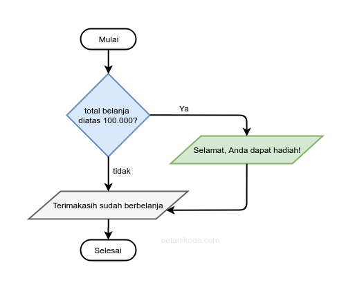

Ada beberapa kondisi yang bisa digunakan, seperti `IF`, `IF-ELSE`, `IF-ELSEIF-ELSE`.

```r
# IF saja
if (a < b) {
  print("nilai a lebih kecil daripada b")
}
```

```
## [1] "nilai a lebih kecil daripada b"
```

```r
# IF-ELSEIF
if (b > c) {
  print("nilai b lebih besar daripada c")
} else if (b == c) {
  print("nilai b sama dengan c")
}
```

```
## [1] "nilai b lebih besar daripada c"
```

```r
# IF-ELSEIF-ELSE
if (a > c) {
  print("nilai a lebih besar daripada c")
} else if (a == c) {
  print("nilai a sama dengan c")
} else {
  print("nilai a lebih kecil daripada c")
}
```

```
## [1] "nilai a lebih kecil daripada c"
```

```r
# CARA LAIN
# Penggunaan ifelse(konsisi, true, false)
p <- TRUE
ifelse(p, "benar", "salah")
```

```
## [1] "benar"
```

```r
q <- c(TRUE, FALSE, FALSE, TRUE, FALSE, FALSE, FALSE)
ifelse(!q, "benar", "salah")
```

```
## [1] "salah" "benar" "benar" "salah" "benar" "benar" "benar"
```

Ada juga cara lain untuk penggunakan percabangan tersebut, seperti `SWITCH`.

```r
# SWITCH
# Secara umum Switch mirip dengan fungsi IF

m <- 1:20 # nilai m adalah 1, 2, 3, ..., 20
type <- "mean"
switch(type,
  mean = mean(m),
  median = median(m),
  range = range(m),
  sd = sd(m),
  var = var(m),
  stop("Type salah")
)
```

```
## [1] 10.5
```

## Perulangan (while-repeat-for looping)

Perulangan merupakan suatu proses dimana kita dapat mengulang satu atau beberapa perintah selama kondisi tersebut terpenuhi. Kita bisa menggunakan `WHILE`, `REPEAT`, `FOR`.

```r
# Looping dengan WHILE
i <- 1
while (i < 6) {
  print(i)
  i <- i + 1
}
```

```
## [1] 1
## [1] 2
## [1] 3
## [1] 4
## [1] 5
```

```r
# Looping dengan repeat -> mirip while
i <- 1
repeat {
  print(i)
  i <- i + 1
  if (i > 5) {
    break
  }
}
```

```
## [1] 1
## [1] 2
## [1] 3
## [1] 4
## [1] 5
```

```r
# Looping dengan FOR
for (x in 1:10) {
  msg <- paste0("Looping ke-", x)
  message(msg)
}
```

```
## Looping ke-1
```

```
## Looping ke-2
```

```
## Looping ke-3
```

```
## Looping ke-4
```

```
## Looping ke-5
```

```
## Looping ke-6
```

```
## Looping ke-7
```

```
## Looping ke-8
```

```
## Looping ke-9
```

```
## Looping ke-10
```

```r
# Looping dari suatu LIST
fruits <- list("apple", "banana", "cherry")
for (y in fruits) {
  print(y)
}
```

```
## [1] "apple"
## [1] "banana"
## [1] "cherry"
```

```r
# Break -> jika ketemu, maka perulangan berhenti
for (z in fruits) {
  if (z == "cherry") {
    break
  }
  print(z)
}
```

```
## [1] "apple"
## [1] "banana"
```

```r
# Next -> jika ketemu, perulangan lanjut setelahnya
for (x in fruits) {
  if (x == "banana") {
    next
  }
  print(x)
}
```

```
## [1] "apple"
## [1] "cherry"
```

```r
# Kombinasi if-else looping
dadu <- 1:6

for (x in dadu) {
  if (x == 6) {
    print(paste("Nomor dadu =", x, "Ketemu!"))
  } else {
    print(paste("Nomor dadu", x, "Ah!Gagal"))
  }
}
```

```
## [1] "Nomor dadu 1 Ah!Gagal"
## [1] "Nomor dadu 2 Ah!Gagal"
## [1] "Nomor dadu 3 Ah!Gagal"
## [1] "Nomor dadu 4 Ah!Gagal"
## [1] "Nomor dadu 5 Ah!Gagal"
## [1] "Nomor dadu = 6 Ketemu!"
```

## Penggunaan Fungsi (dasar)

Fungsi merupakan blok kode yang dirancang untuk melakukan tugas tertentu dan dapat dipanggil berkali-kali dalam program.

```r
# Tanpa parameter
say_hello <- function() {
  print("Halo, semua!")
}
say_hello()
```

```
## [1] "Halo, semua!"
```

```r
# Dengan parameter
say_myname <- function(name) {
  paste("Halo, ", name)
}
say_myname("Eko")
```

```
## [1] "Halo,  Eko"
```

```r
# Ada parameter dan return value
hasil_kali <- function(a, b) {
  return(a * b)
}
hasil_kali(4, 6)
```

```
## [1] 24
```

## Penggunaan Fungsi (advanced)

Penggunaan fungsi pada level selanjutnya dapat dilihat pada contoh kode program berikut, seperti (1) nested function, (2) rekursi, dan (3) penggunakan global dan local variabel.

### Nested function

Nested function merupakah implementasi fungsi dimana bentuknya bersarang (ada fungsi di dalam fungsi).

```r
# 1. Nested function --> ada fungsi di dalam fungsi

fungsi_bersarang <- function(a, b) {
  return(a + b)
}
fungsi_bersarang(fungsi_bersarang(2, 3), fungsi_bersarang(4, 5))
```

```
## [1] 14
```

```r
# step 1: fungsi_bersarang(2, 3) akan diproses hasilnya = 5
# step 2: fungsi_bersarang(4, 5) akan diproses hasilnya = 9
# step 3: fungsi_bersarang(5, 9) akan diproses hasilnya = 14

fungsi_luar <- function(x) {
  fungsi_dalam <- function(y) {
    return(x + y)
  }
  return(fungsi_dalam)
}
output <- fungsi_luar(5)
output(9)
```

```
## [1] 14
```

```r
# fungsi_luar mengembalikan sebuah fungsi, yaitu fungsi_dalam
# sehingga perlu ada variabel baru, misal output untuk menangkap fungsi
# step 1: fungsi_luar(5) akan dijalankan mengambalikan fungsi_dalam
# 5 adalah nilai x
# step 2: output(9) dijalankan akan menjadi nilai y
# step 3: output(9) sama dengan menjalankan fungsi_dalam, yaitu 5 + 9 = 14
```

### Rekursi

Rekursi merupakan metode pengulangan yang melibatkan penggunaan dirinya sendiri. Dalam konteks pemrograman, fungsi rekursif adalah suatu bentuk perulangan yang tidak melibatkan iterasi.

```r
# 2. Rekursi -> fungsi yang memanggil dirinya sendiri

faktorial <- function(x) {
  if (x == 0) {
    return(1)
  } else {
    return(x * faktorial(x - 1))
  }
}
faktorial(5)
```

```
## [1] 120
```

```r
# step 1: faktorial(5), x = 5, return 5 * faktorial(4)
# step 2: faktorial(4), x = 4, return 5 * 4 * faktorial(3)
# step 3: faktorial(3), x = 3, return 5 * 4 * 3 * faktorial(2)
# step 4: faktorial(2), x = 2, return 5 * 4 * 3 * 2 * faktorial(1)
# step 5: faktorial(1), x = 1, return 5 * 4 * 3 * 2 * 1 * faktorial(0)
# step 6: faktorial(0), x = 0, return 5 * 4 * 3 * 2 * 1 * 1 = 120
```

### Global dan Local Varibel

Global variabel merupakan variabel yang dibuat di luar fungsi dan bisa diakses dimana saja oleh seluruh bagian program. Keberadaan variabel ini memudahkan penggunaan data yang sama di berbagai fungsi tanpa perlu mendeklarasikannya kembali. Variabel lokal dideklarasikan di dalam fungsi atau blok kode dan hanya bisa diakses dalam lingkup tersebut. Ada beberapa contoh yang bisa diterapkan dalam penggunaan variabel global dan lokal tersebut dan bisa dilihat pada contoh kode program berikut.

```r
# 3. Global variables -> variabel yang dibuat di luar fungsi

# Contoh 1:
# teks di dalam function akan menggunakan variabel yang ada di luar (global)
teks <- "awesome!"
contoh1_function <- function() {
  paste("R itu", teks)
}
contoh1_function()
```

```
## [1] "R itu awesome!"
```

```r
# Contoh 2:
# teks di dalam function akan menggunakan variabel yang ada di dalam (local)
teks <- "superb!"
contoh2_function <- function() {
  teks <- "awesome!"
  paste("R itu", teks)
}
contoh2_function() # akan memanggil variabel teks di dalam
```

```
## [1] "R itu awesome!"
```

```r
sprintf("R itu %s", teks)
```

```
## [1] "R itu superb!"
```

```r
# Contoh 3:
# teks di dalam function akan menjadi variabel global
contoh3_function <- function() {
  teks <<- "awesome!"
  paste("R itu", teks)
}
contoh3_function()
```

```
## [1] "R itu awesome!"
```

```r
sprintf("R itu %s", teks)
```

```
## [1] "R itu awesome!"
```

```r
# Contoh 4:
# teks di dalam function akan menjadi variabel global
# mengganti variabel global sebelumnya di luar fungsi
teks <- "funtastic!"
contoh4_function <- function() {
  teks <<- "awesome!"
  paste("R itu", teks)
}
contoh4_function()
```

```
## [1] "R itu awesome!"
```

```r
sprintf("R itu %s", teks)
```

```
## [1] "R itu awesome!"
```